# GAE7

Author

Jill Dixon

## Introduction

Pintar et al. (2018) conducted a field mesocosm experiment to explore the relative effects of predation risk and nutrient availability (a pdf of their publication is included in the GitHub repository). The predation risk manipulation was accomplished by adding either 0, 1, or 2, Golden Topminnows (*Fundulus chrysotus*) to each mesocosm. These small fish are surface-feeding predators and are known to elicit colonization and oviposition avoidance among dytiscid beetles and *Culex* mosquitoes, but not in some hydrophilid beetles. Nutrient-level treatments were created by the addition of 0, 4, or 8 g of rabbit chow (Small World Rabbit Food, Mannapro, St. Louis, MO, 40% protein).

## Methods

Please see Pintar et al. (2018) for greater detail on experimental design and data collection. In brief, the experiment was set up as a 3 X 3 factorial treatment design (9 treatment combinations). The experiment was replicated in 3 separate locations at 3 different times for a total of 9 replicates. This should have resulted in 81 observations total, however some fish died during the experiment rendering those observations not being included in the data resulting in only 69 observations.

### Statistical Methods

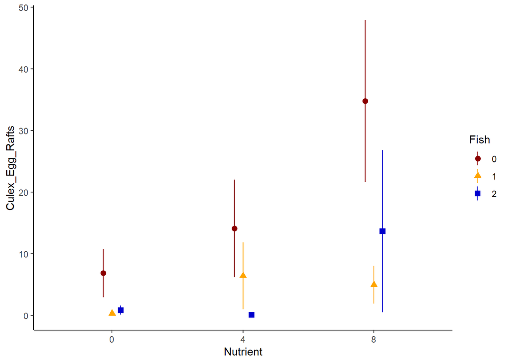

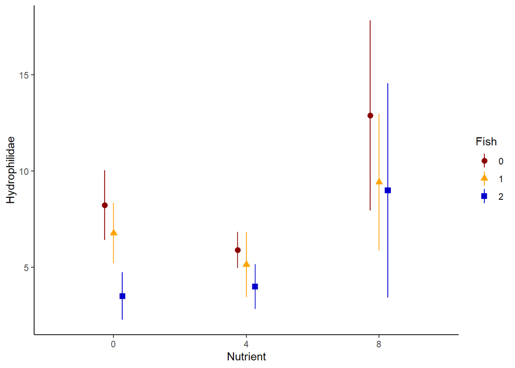

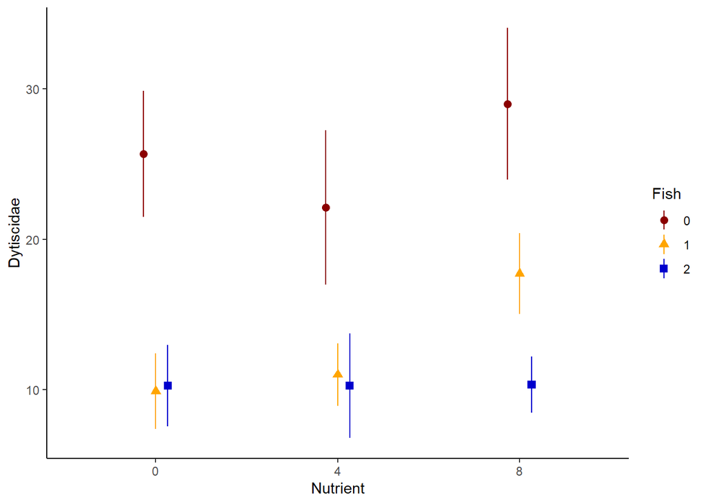

## References

Pintar, M. R., J. R. Bohenek, L. L. Eveland, and W. J. Resetarits. 2018. Colonization across gradients of risk and reward: Nutrients and predators generate species-specific responses among aquatic insects. Functional Ecology 32:15891598.